# Lab 5: The Linear Model (Part 1)

INTS 4735

Did you enjoy your week off from R? Wait, what? You still used R last week? Well, that’s good too.

As usual, you can remove extraneous data from your workspace with the `remove(list=ls())` command. Perhaps a better option though would be to start a new project. Click File -> New Project and you’ll be prompted to create a folder where your files and local data will live – away from the other work that you’re doing. You can also move back and forth from projects with relative ease. [Here](https://support.rstudio.com/hc/en-us/articles/200526207-Using-Projects) is some more help using Porjects in RStudio. Explore. Experiment. Then move on to the exercise.

No random groups today. Find a group of three (and if absolutely necessary, four) people that will help you learn. If you’re having trouble, don’t necessarily choose other people that are having trouble. If you are more comfortable with R, join a group where you can help others work through issues. Advice for everyone: be patient but keep at it. Remember that part of the class is practice collaborating.

# Peacekeeping

Last week, several of you presented pieces on civil wars. In two of the pieces (Regan 2003; Cunningham 2006), we decided that the focus on duration left out the human costs of civil conflict. Regan in particular, found that outside intervention tended to make conflicts longer but we wanted to know if such intervention made conflicts more deadly.

This week, we will look at a piece by Hultman, Kathman, and Shannon (2013) that looks at the effect of peacekeeping activities on civilian casualties. You can find the original article [here](http://onlinelibrary.wiley.com/doi/10.1111/ajps.12036/abstract) and read a summary of the findings (along with some others) in the [Global Policy Journal](http://www.globalpolicyjournal.com/blog/04/03/2015/effectiveness-peacekeeping-during-civil-war).[^1]

No. Really. Take a few minutes and read/skim one or the other. There’s no reason to rush into a data exercise without understanding the “what” and “why.”

## Dataset

Download and import the dataset from canvas. You can also download the data [here](https://dataverse.harvard.edu/dataset.xhtml?persistentId=hdl:1902.1/21043). I will be using the `rdata` format for the top file.

```r
# As always, you'll have to change your file path. If someone in your group is having trouble, please help them out.
load("~/Dropbox/Teaching/fall-2017/dsm-ints4735-fall2017/data/HKS-civilian-protection/HKS_AJPS_2013.rdata")

# I don't like the name 'x' for the dataset. We'll name it after the authors' last names
hks <- x
remove(x)
```

## Brief Description of Data

The authors do not include a codebook – at least not on the dataverse link. This is frustrating. I will describe the case selection and a few of the variables here (using the langauge from Nachmias and some notation from Kaplan). For the moment, we will shelve any concerns about reliability and validity.

- Sample: All of the cases contained in this dataset are from instances of rebel-state according to the UCDP/PRIO Armed Conflict dataset[^2]. The cases are limited to Sub-Saharan Africa between the years of 1991-2008. In total, they cover 36 armed conflicts. In 12 of the cases, there is a peacekeeping operation.  
  The `location` variable and `sideA` contain names for countries/governments in the conflict. `sideB` identifies the rebel group.
- Unit/Level of Analysis: Realize that the LOA for this dataset is the country-month. That’s why there are almost 4000 observations for only 36 civil wars. Both `year` and `mon` (month) are necessary to uniquely identify each row since we are dealing with country-month observations.
- Outcome Variable: *One-sided violence* or violence directed at civilians. You’ll see this in the dataset as `osvall` or related varaibles `ovsreb` and `osvgovt` which are specific to civilians killed be the rebels and government.
- Explanatory Variables: There is more than one but all related to *peacekeeping*. The first that we will use is `PKOdum` a numeric value representing if a peacekeeping operation (PKO) is present in a given month. Like Nachmias and Nachmias describe in their measurement chapter, a “dummy” variable refers to a 0/1 representation of absence/presence.  
  The other variables that we’ll look at today are *troop size*, *police size*, and *military observer size*. The variables in the dataset represent the number of these types of peacekeeping personel with the names `troopLag`, `policeLag`, and `militaryobserversLag`. Recall our discussion of causation. Why are each of these variables appended with “Lag?”

There are several other variables in the dataset that you may want to look at later, but these are all that we will use today. Look at a quick summary of the dataset using the `glimpse()` command.

```r
require(tidyverse)
glimpse(hks)
```

```
## Observations: 3,972
## Variables: 36
## $ conflict_id           <dbl> 70, 70, 70, 70, 70, 70, 70, 70, 70, 70, ...
## $ id_ep                 <int> 701, 701, 701, 701, 701, 701, 701, 701, ...
## $ gwnoloc               <int> 530, 530, 530, 530, 530, 530, 530, 530, ...
## $ year                  <int> 1991, 1991, 1991, 1991, 1991, 1991, 1991...
## $ mon                   <dbl> 1, 2, 3, 4, 5, 6, 7, 8, 9, 10, 11, 12, 1...
## $ location              <S3: AsIs> Ethiopia, Ethiopia, Ethiopia, Ethio...
## $ sidea                 <S3: AsIs> Ethiopia, Ethiopia, Ethiopia, Ethio...
## $ sidea2nd              <S3: AsIs> NA, NA, NA, NA, NA, NA, NA, NA, NA,...
## $ sideb                 <S3: AsIs> EPRDF, EPRDF, EPRDF, EPRDF, EPRDF, ...
## $ sideb2nd              <S3: AsIs> NA, NA, NA, NA, NA, NA, NA, NA, NA,...
## $ mission               <S3: AsIs> NA, NA, NA, NA, NA, NA, NA, NA, NA,...
## $ PKOdum                <dbl> NA, 0, 0, 0, 0, 0, 0, 0, 0, 0, 0, 0, 0, ...
## $ osvAll                <dbl> 29, 4, 1, 1, 2, 0, 0, 0, 0, 0, 0, 0, 0, ...
```

[output cut: 23 more lines]

You should also look at a `summary()` of the outcome variable. There is one aspect of *one-sided violence* that will probably jump out at you immediately.

```r
summary(hks$osvAll)
```

```
##      Min.   1st Qu.    Median      Mean   3rd Qu.      Max.
##      0.00      0.00      0.00     66.04      0.00 145844.00
```

Try to interpret, in substantive terms, what this means. You can generate a histogram or boxplot of this variable as well, but I will tell you now that they are not too informative.

# Linear Regression

Both the Kaplan and Nachmias & Nachmias readings include a discussion of linear regression as one type of model or representation of a relationship. We will apply linear regression or Ordinary Least Squares (OLS) regression[^3] here to produce a number of estimates for the effect of peacekeeping on civilian casualties since the outcome variable is a continuous measure. Recall from N&N that there are other types of tests that are more suitable for nominal and ordinal outcomes.

> How would you use the notation in Kaplan to represent such a relationship? Take a second to do this – you’re about to use it a lot.

## The `lm()` Command

The `lm()` command has many options and variants. The most basic looks like this:

```r
lm(outcome ~ explanatory, data = ???)
```

If you ever forget the order for the variables, remember you can type `?lm` for the help menu.

Let’s try this with the `hks` dataset.

```r
lm(osvAll ~ PKOdum, data = hks)
```

```
##
## Call:
## lm(formula = osvAll ~ PKOdum, data = hks)
##
## Coefficients:
## (Intercept)       PKOdum
##       27.37       262.97
```

The output provides an intercept and a coefficient, both of which we’ll explore more in the subsequent sections. Before that, though, make sure that you understand the syntax by fitting a model that has `osvgov` (the number of civilians killed by the government, per month) as the outcome/response variable and `lntpop` (the natural log of the total population) as the explanatory variable.

## Readable Tables

Many of the articles that you’l read in academic journals will include regression output – but in a nicer format than we see in the R console. Here is one example.

```r
# You may have to install this package
# install.packages("xtable")
require(xtable)
options(xtable.comment = FALSE) # Removes some extra stuff. You can comment this out and see what things look like

lm1 <- lm(osvAll ~ PKOdum, data = hks) # save model in an object called "lm1"
tab1 <- xtable(summary(lm1), digits=c(0, 2, 2, 1, 2))
print(tab1, type="html")
```

|  | Estimate | Std. Error | t value | Pr(>\|t\|) |
| --- | --- | --- | --- | --- |
| (Intercept) | 27.37 | 40.78 | 0.7 | 0.50 |
| PKOdum | 262.97 | 105.24 | 2.5 | 0.01 |

The pdf output for this actually looks a lot better, but again only really applies when we’re knitting. Hey, maybe you’ll see this again later in the assignment.

```r
# To do this when knitting to pdf
xtable(lm1, type = "latex", digits=c(0, 2, 2, 1, 2))
```

## Coefficients, Units, and Effect Size

Remember that the output for a linear model is in the form of a linear equation and carries with it the units from the specific variables. Interpret the output from the linear model below:

```r
lm(osvAll~PKOdum, data=hks)
```

```
##
## Call:
## lm(formula = osvAll ~ PKOdum, data = hks)
##
## Coefficients:
## (Intercept)       PKOdum
##       27.37       262.97
```

You should be able to answer the following questions:  
1. Based on the linear model, how many causalties should we expect if there is no peacekeeping operation? 2. How many civilian casualties should we expect if there is a peacekeeping operation? 3. What kind of relationship exists here (use the Nachmias & Nachmias language)?  
4. Is this a substantially large effect?  
5. What’s surprising about this effect? Can you explain why we might see such an effect? Do peacekeepers *cause* this outcome?

## A Difference of Means

One thing that you’ll may have noticed is that when you have a categorical explanatory variable, the linear model is simply reporting the difference of means across groups. For the special dichotamous or “dummy” variable that indicates the presence of a Peacekeeping Operation (`PKOdum`), we are just seeing the average number of casualties with and without peacekeepers. Don’t believe me. Try the following and see if there are any numbers that look familiar.

```r
with(filter(hks, PKOdum==0), mean(osvAll))
with(filter(hks, PKOdum==1), mean(osvAll))
with(filter(hks, PKOdum==1), mean(osvAll)) - with(filter(hks, PKOdum==0), mean(osvAll))
```

## More Differences of More Means: Interaction Terms with Categorical Variables

The Kaplan talks about interaction terms. Consider this next section a bit of a detective work. Use the commands that I left below to generate the same values that you see in the output for the linear model: `osvAll~PKOdum*ceasefire`. What do the numbers represent here? Because I forgot to mention it, `ceasefire` is another “dummy” variable that indicates if a ceasefire is active during a specific month.

```r
lm(osvAll~PKOdum*ceasefire, data=hks)
```

```
##
## Call:
## lm(formula = osvAll ~ PKOdum * ceasefire, data = hks)
##
## Coefficients:
##      (Intercept)            PKOdum         ceasefire  PKOdum:ceasefire
##           30.034            22.764             3.201           939.489
```

```r
table(hks$PKOdum, hks$ceasefire)

with(hks %>% filter(ceasefire==0, PKOdum==0), mean(osvAll))
```

## Predicted Values

Okay, so a model is not the same as reality. Next week we’ll talk about what specific criterial OLS uses to fit a slope and intercept[^4] but until then, let’s measure the gap between the model’s prediction and an observed outcome. Remember how we do this because it’ll come back next week.

Let’s pull out a specific Peackeeping Operation from the dataset.

```r
# Run this
hks[188, c(6,4,5,7,11,12,13)]
```

What do we know about this observation? When does it occur? Where? How many civilian die?

How about this one?

```r
hks[104, c(6,4,5,7,11,12,13)]
```

```
##                                 location year mon
## 104 Democratic Republic of Congo (Zaire) 1998   8
##                                    sidea mission PKOdum osvAll
## 104 Democratic Republic of Congo (Zaire)    <NA>      0   1802
```

Let’s see what the linear model predicts for the number of civilian killed based on the presence of peacekeepers.

```r
# What does this line do?
lm1$coefficients[1]+lm1$coefficients[2]*1
```

```
## (Intercept)
##    290.3486
```

```r
lm1$coefficients[1]+lm1$coefficients[2]*0
```

```
## (Intercept)
##     27.3744
```

So the predictions aren’t perfect. In these two cases, they’re quite off.

## Visualizing the Linear Model

The visual for the relationship between PKO and Civilian Casualties is not great, but here it is. You can use this for reference in the next section.

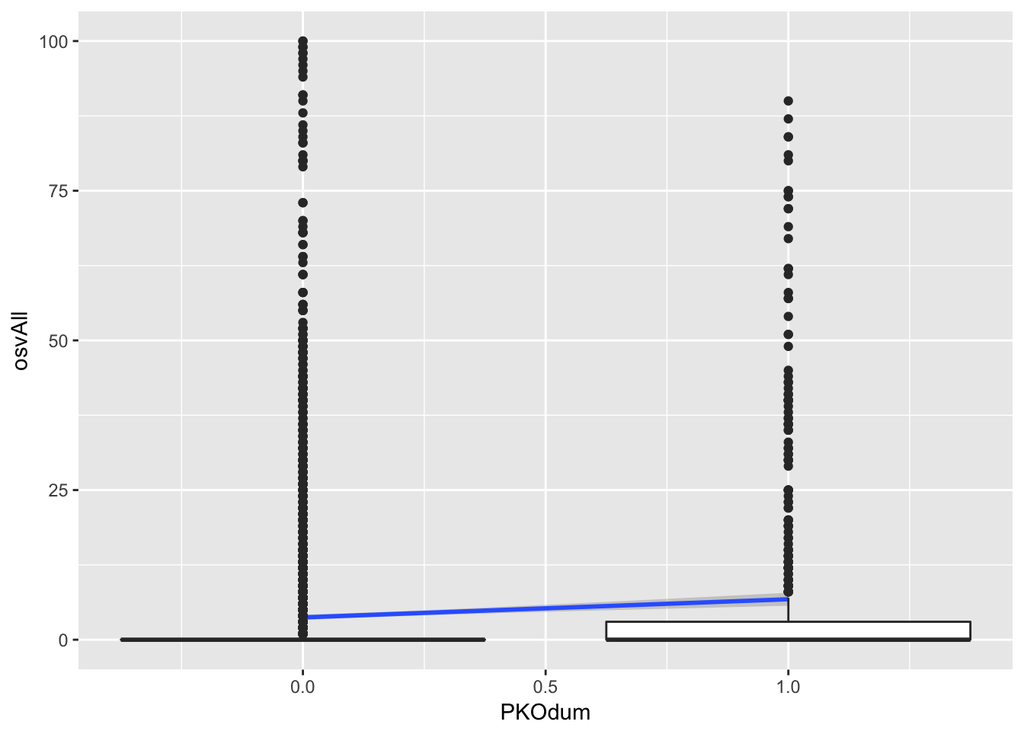

```r
ggplot(data=hks, aes(x=PKOdum, y=osvAll)) +
  stat_smooth(method="lm") +
  geom_boxplot(aes(group=PKOdum)) +
  ylim(0,100) # Hum, what happens when you get rid of this line?
```

# Vignette

Welcome to your first day at [UNPKO](http://www.un.org/en/peacekeeping/). Part of your job while you’re here will be to help us put together some media to bolster our public image. As you’re probably already aware, we’ve had a number of recent scandals including our role in a [cholera outbreak in Haiti](http://www.npr.org/sections/thetwo-way/2016/08/18/490468640/u-n-admits-role-in-haiti-cholera-outbreak-that-has-killed-thousands), critisisms of our effectiveness in [South Sudan](https://www.theguardian.com/world/2016/aug/15/south-sudan-aid-worker-rape-attack-united-nations-un_), and peacekeeper “misconduct” in [many other peacekeeping missions](http://www.news24.com/Africa/News/un-to-tackle-claim-it-mishandles-car-rape-cases-20170916).

We want to shine a light on some of the good that peacekeeping operations do, starting with how peacekeepers help protect civilian populations. There was an article that a bunch of academics published several years ago – I think you just read about it. We want to pull a few numbers out of their piece and simplify them so that they can go in a brief report. Nothing too complicated at this stage, just tell me how many deaths peacekeepers prevent when they are deployed. You can do that, right?

## Task 1: Explain

You already know that the relationship between PKOdum and osvAll is positive. That is, PKO operations are associated with more civilian casualties. Explain to your new boss why this is the case. Is the UN causing more civilian deaths?

## Task 2: Fit a New Model

Choose one of the other variables in the dataset that deals with the deployment of specific types of peacekeeping personel (police, military observers, troops). Fit a model that represents the relationship between that type of troop number and civilian casualties. Restrict your analysis to cases where there are peacekeeping operations.

## Task 3: Interpret the Model

Explain the effect of a specific type of personel on civilian casualties. Make sure you keep in mind the units when explaining this. Restrict your analysis to cases in the dataset where there is a peacekeeping operation.

Now fit two other models for the other variables concerning specific personel types and interpret those.

What are the typical values for the troop variables? Does that change your interpretation of the size of the effect?

## Task 4: Present the Model

Present the output of one of these models in a table. Try to make it look nice since it’ll be going in a report.

Also create a scatter plot with a line that represents the linear model. For help, see exercise 3 or consult an online source (Google).

What critiques do you have about the model? Does it represent a causal relationship? Why or why not?

## Turn it in

When you are complete, turn if what you have. Again, if you didn’t finish everything that is fine but turn in something so that I can count it towards attendance. This is a shorter assignment so I do hope that you at least attempt most of these tasks. If you don’t complete them now, try them at home – maybe with your own dataset. This is something that you’ll probably use for your final paper.

[^1]: The link wasn’t working last time I clicked it, so [here](http://webcache.googleusercontent.com/search?q=cache:Td63Sbtq0DAJ:www.globalpolicyjournal.com/blog/04/03/2015/effectiveness-peacekeeping-during-civil-war+&cd=1&hl=en&ct=clnk&gl=us) is a cached version.
[^2]: Recall that one of the requirements for an armed conflict is that is kills more than 25 combatants in a year
[^3]: While we use OLS here, the authors do not because they are concerned with the distribution of their outcome variable. Since we are not looking at statistical significance (yet), we aren’t concerned with bias standard errors. OLS will do, and would probably be okay/as good their approach – but this is a topic that is outside the scope of DSM.
[^4]: A hint: it’s in the name.